# logistic_regression_example

Dan Ladd

### In this supervised machine learning application, I use logistic regression to assess if an employee is *at risk* of leaving an organization based on attributes and characteristics of their employment.

### After loading the data and performing basic cleaning, I discover that the sample needs to be balanced so classes are roughly equal for the target feature. Given logistic regression can be sensitive to small sample sizes, I rebalance my sample using an oversampling technique. I then review descriptive statistics and plot visuals for both numerical and categorical features. After gaining a baseline, I look at feature correlation and decide to reduce dimensions to avoid potential mulicollinearity issues.

### I then begin the machine learning process. After partitioning and training my logistic regression model, I evaluate its perfromance against the validation data set. I utalize a confusion matrix and AUC-ROC plot to understand and visualize the models perfromance.

```r
library(tidyverse)
library(psych)
library(corrplot)
library(car)
library(mlr)
library(mlr3)
library(mlr3learners)
library(rpart)
library(caret)
library(pROC)
```

**Load and Preview data**  
In this project, I’m interested in learning about how different employee attributes and characteristics contribute to corporate attrition. I’ll use the *at.risk* feature as my target. A value of *Yes* is given for an employee who has left the company, and a value of *No* is given to retained employees. Statistics will help me understand if and how predictor features relate to the target.

A preview of the data shows me it has been read into R and organized as a data.frame. There are twelve features including the target feature. Some features are categorical and others numerical. There are both discrete and continuous features.

```r
# load data into environment
employee_data <- read.csv("C:\\Users\\DLadd\\OneDrive - New England College\\Dan\\Data Science\\Portfolio\\data sets\\HR_Analytics.csv")

# preview data
head(employee_data, 10)
```

```
##    ï..attrition gender age education job.level performance.rating
## 1           Yes Female  41         2         2                  3
## 2            No   Male  49         1         2                  4
## 3           Yes   Male  37         2         1                  3
## 4            No Female  33         4         1                  3
## 5            No   Male  27         1         1                  3
## 6            No   Male  32         2         1                  3
## 7            No Female  59         3         1                  4
## 8            No   Male  30         1         1                  4
## 9            No   Male  38         3         3                  4
## 10           No   Male  36         3         2                  3
##    yrs.in.current.role yrs.since.promotion yrs.with.manager yrs.at.company
## 1                    4                   0                5              6
## 2                    7                   1                7             10
## 3                    0                   0                0              0
```

[output cut: 18 more lines]

**Basic organization and understanding**  
I rename the target and then manually document each features level of measurement in a list. This helps me determine what types of statistical analysis and modeling are appropriate later on in the project.

```r
# rename attrition feature to at.risk for clarity
employee_data <- employee_data %>%
  rename(at.risk = 'ï..attrition')
```

```r
# create list containing level of measurement for each feature
feature_types <- list(
  "at.risk" = "nominal",
  "gender" = "nominal",
  "age" = "ratio",
  "education" = "ordinal",
  "job.level" = "ordinal",
  "performance.rating" = "ordinal",
  "yrs.in.current.role" = "ratio",
  "yrs.since.promotion" = "ratio",
  "yrs.with.manager" = "ratio",
  "yrs.at.company" = "ratio",
  "monthly.income" = "ratio",
  "job.travel.requirements" = "nominal"
)

# view list
feature_types
```

```
## $at.risk
## [1] "nominal"
##
## $gender
## [1] "nominal"
##
## $age
## [1] "ratio"
##
## $education
## [1] "ordinal"
##
## $job.level
## [1] "ordinal"
##
## $performance.rating
## [1] "ordinal"
##
## $yrs.in.current.role
## [1] "ratio"
##
## $yrs.since.promotion
## [1] "ratio"
##
## $yrs.with.manager
## [1] "ratio"
##
## $yrs.at.company
## [1] "ratio"
##
## $monthly.income
## [1] "ratio"
##
## $job.travel.requirements
## [1] "nominal"
```

I then review the structure of the data. Upon reviewing the structure, I recognize the need to change the feature formats to correspond with their levels of measurement. It’s also worth noting that *education* and *job.level* should be converted from numerical to categorical since their numerical values represent categories.

```r
# review the structure of the data
str(employee_data)
```

```
## 'data.frame':    1470 obs. of  12 variables:
##  $ at.risk               : chr  "Yes" "No" "Yes" "No" ...
##  $ gender                : chr  "Female" "Male" "Male" "Female" ...
##  $ age                   : int  41 49 37 33 27 32 59 30 38 36 ...
##  $ education             : int  2 1 2 4 1 2 3 1 3 3 ...
##  $ job.level             : int  2 2 1 1 1 1 1 1 3 2 ...
##  $ performance.rating    : int  3 4 3 3 3 3 4 4 4 3 ...
##  $ yrs.in.current.role   : int  4 7 0 7 2 7 0 0 7 7 ...
##  $ yrs.since.promotion   : int  0 1 0 3 2 3 0 0 1 7 ...
##  $ yrs.with.manager      : int  5 7 0 0 2 6 0 0 8 7 ...
##  $ yrs.at.company        : int  6 10 0 8 2 7 1 1 9 7 ...
##  $ monthly.income        : int  5993 5130 2090 2909 3468 3068 2670 2693 9526 5237 ...
##  $ job.travel.requirments: chr  "Travel_Rarely" "Travel_Frequently" "Travel_Rarely" "Travel_Frequently" ...
```

```r
# make changes noted above
## convert nominal features into factors
employee_data$at.risk <- as.factor(employee_data$at.risk)
employee_data$gender <- as.factor(employee_data$gender)
employee_data$job.travel.requirments <- as.factor( employee_data$job.travel.requirments)

## convert ordinal features into ordered factors
employee_data$education <- ordered(employee_data$education)
employee_data$job.level <- ordered(employee_data$job.level)
employee_data$performance.rating <- ordered(employee_data$performance.rating)

## convert ratio features into numerics
employee_data$age <- as.numeric(employee_data$age)
employee_data$yrs.in.current.role <- as.numeric(employee_data$yrs.in.current.role)
employee_data$yrs.since.promotion <- as.numeric(employee_data$yrs.since.promotion)
employee_data$yrs.with.manager <- as.numeric(employee_data$yrs.with.manager)
employee_data$yrs.at.company <- as.numeric(employee_data$yrs.at.company)
employee_data$monthly.income <- as.numeric(employee_data$monthly.income)

## convert data.frame into tibble
employee_data <- as_tibble(employee_data)

# view new structure
str(employee_data)
```

```
## tibble [1,470 x 12] (S3: tbl_df/tbl/data.frame)
##  $ at.risk               : Factor w/ 2 levels "No","Yes": 2 1 2 1 1 1 1 1 1 1 ...
##  $ gender                : Factor w/ 2 levels "Female","Male": 1 2 2 1 2 2 1 2 2 2 ...
##  $ age                   : num [1:1470] 41 49 37 33 27 32 59 30 38 36 ...
##  $ education             : Ord.factor w/ 5 levels "1"<"2"<"3"<"4"<..: 2 1 2 4 1 2 3 1 3 3 ...
##  $ job.level             : Ord.factor w/ 5 levels "1"<"2"<"3"<"4"<..: 2 2 1 1 1 1 1 1 3 2 ...
##  $ performance.rating    : Ord.factor w/ 2 levels "3"<"4": 1 2 1 1 1 1 2 2 2 1 ...
##  $ yrs.in.current.role   : num [1:1470] 4 7 0 7 2 7 0 0 7 7 ...
##  $ yrs.since.promotion   : num [1:1470] 0 1 0 3 2 3 0 0 1 7 ...
##  $ yrs.with.manager      : num [1:1470] 5 7 0 0 2 6 0 0 8 7 ...
##  $ yrs.at.company        : num [1:1470] 6 10 0 8 2 7 1 1 9 7 ...
##  $ monthly.income        : num [1:1470] 5993 5130 2090 2909 3468 ...
##  $ job.travel.requirments: Factor w/ 3 levels "Non-Travel","Travel_Frequently",..: 3 2 3 2 3 2 3 3 2 3 ...
```

**Missing Data**  
It’s a miracle. There is no missing data! Typically, cleaning missing data is the logical next step. Cleaning missing data can be performed using several different imputation stratigies. The preferred strategy is often based on domain knowledge. Excessive missing data may result in dimension reduction via removing features all together. Failure to handle missing data can easily lead to poor insights, forecasts, and model building.

```r
# review NA occurrences in the data set
colSums(is.na(employee_data))
```

```
##                at.risk                 gender                    age
##                      0                      0                      0
##              education              job.level     performance.rating
##                      0                      0                      0
##    yrs.in.current.role    yrs.since.promotion       yrs.with.manager
##                      0                      0                      0
##         yrs.at.company         monthly.income job.travel.requirments
##                      0                      0                      0
```

**Check for duplicated observations**  
I then check for duplicated observations. There are no duplicated observations.

```r
employee_data %>%
  filter(duplicated(.))
```

```
## # A tibble: 0 x 12
## # i 12 variables: at.risk <fct>, gender <fct>, age <dbl>, education <ord>,
## #   job.level <ord>, performance.rating <ord>, yrs.in.current.role <dbl>,
## #   yrs.since.promotion <dbl>, yrs.with.manager <dbl>, yrs.at.company <dbl>,
## #   monthly.income <dbl>, job.travel.requirments <fct>
```

**Review target feature class balance** It’s important to have a good balance of the target features classes when applying logistic regression to classification problems. After discovering the target imbalance, I use an oversampling technique to rebalance the data.

```r
# review balance of target variables classes
table(employee_data$at.risk) / nrow(employee_data)
```

```
##
##        No       Yes
## 0.8387755 0.1612245
```

```r
# rebalance target by oversampling "yes"
employee_data <- upSample(x = employee_data[, -which(names(employee_data) == "at.risk")], y = employee_data$at.risk)

# re institute feature name and check new balance
employee_data <- employee_data %>%
  rename(at.risk = Class)

table(employee_data$at.risk)
```

```
##
##   No  Yes
## 1233 1233
```

**Descriptive Statistics of Numerical Features**  
Now that I’ve gained a basic understanding of the data and performed some preliminary preprocessing, I’m ready to take a closer look at each feature and gain a general impression.

```r
# review central tendency and dispersion of numerical features
# review frequency distributions of categorical features

desc_stat_num_vars <- employee_data[c("age", "yrs.in.current.role", "yrs.since.promotion", "yrs.with.manager", "yrs.at.company", "monthly.income")]

summary(desc_stat_num_vars)
```

```
##       age        yrs.in.current.role yrs.since.promotion yrs.with.manager
##  Min.   :18.00   Min.   : 0.000      Min.   : 0.000      Min.   : 0.000
##  1st Qu.:29.00   1st Qu.: 1.000      1st Qu.: 0.000      1st Qu.: 0.000
##  Median :34.00   Median : 2.000      Median : 1.000      Median : 2.000
##  Mean   :35.41   Mean   : 3.599      Mean   : 1.984      Mean   : 3.483
##  3rd Qu.:42.00   3rd Qu.: 7.000      3rd Qu.: 2.000      3rd Qu.: 7.000
##  Max.   :60.00   Max.   :18.000      Max.   :15.000      Max.   :17.000
##  yrs.at.company   monthly.income
##  Min.   : 0.000   Min.   : 1009
##  1st Qu.: 2.000   1st Qu.: 2587
##  Median : 5.000   Median : 4284
##  Mean   : 6.053   Mean   : 5717
##  3rd Qu.: 8.000   3rd Qu.: 7102
##  Max.   :40.000   Max.   :19999
```

```r
describe(desc_stat_num_vars)
```

```
##                     vars    n    mean      sd median trimmed     mad  min   max
## age                    1 2466   35.41    9.66     34   34.86    8.90   18    60
## yrs.in.current.role    2 2466    3.60    3.46      2    3.17    2.97    0    18
## yrs.since.promotion    3 2466    1.98    3.10      1    1.28    1.48    0    15
## yrs.with.manager       4 2466    3.48    3.41      2    3.07    2.97    0    17
## yrs.at.company         5 2466    6.05    6.06      5    4.94    4.45    0    40
## monthly.income         6 2466 5716.78 4356.76   4284 4897.30 2787.29 1009 19999
##                     range skew kurtosis    se
## age                    42 0.50    -0.39  0.19
## yrs.in.current.role    18 1.10     0.88  0.07
## yrs.since.promotion    15 2.17     4.59  0.06
## yrs.with.manager       17 0.98     0.43  0.07
## yrs.at.company         40 2.19     6.48  0.12
## monthly.income      18990 1.60     2.04 87.73
```

**Outlier Desicioning** I have to decide how to handle the outliers. I review each outlier and decide weather it’s meaningful to our objective or not. A data entry typo would not be meaningful for example. Domain and project knowledge guide me in deciding weather or not to keep outliers. After scrutinizing each features outliers, I determine that they are all reasonable and relevant to the problem we’re drawing insights on. Ultimately, I keep all ourliers.

*yrs.in.current.role outliers*  
Examining the boxplot shows me that I have at least two outliers in the *yrs.in.current.role* feature. To take a closer look, I calculate the IQR, lowerbound, and upper bound. I’m then able to identify and print a tibble of the observations with outliers in *yrs.at.current.role*. I can see that there are actually 6 outliers in this feature. All appear to be litigant and reasonable observations that will provide value to my model. I choose to keep outliers since they should have a positive effect on the accuracy of my model.

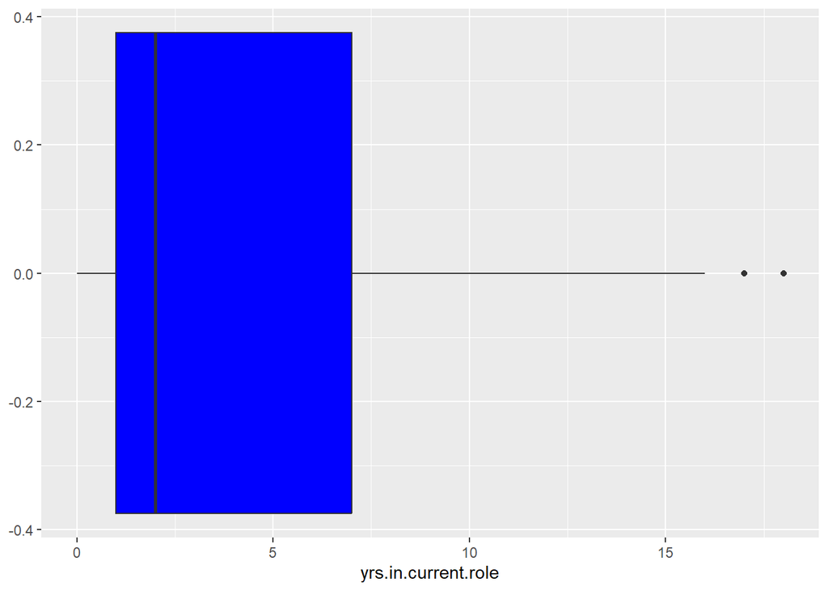

```r
# boxplot of yrs.in.current.role
ggplot(employee_data, mapping = aes(yrs.in.current.role)) +
  geom_boxplot(fill = "blue")
```

```r
# Calculate Q1, Q3, and IQR
current_role_q1 <- quantile(employee_data$yrs.in.current.role, 0.25)
current_role_q3 <- quantile(employee_data$yrs.in.current.role, 0.75)
current_role_iqr <- current_role_q3 - current_role_q1

# Define the lower and upper bounds for outliers
current_role_lb <- current_role_q1 - 1.5 * current_role_iqr
current_role_ub <- current_role_q3 + 1.5 * current_role_iqr

# Extract outliers
current_role_outliers <- employee_data$yrs.in.current.role[employee_data$yrs.in.current.role < current_role_lb | employee_data$yrs.in.current.role > current_role_ub]

# Print outliers
employee_data[employee_data$yrs.in.current.role < current_role_lb |employee_data$yrs.in.current.role > current_role_ub, ]
```

```
##      gender age education job.level performance.rating yrs.in.current.role
## 104    Male  51         3         5                  3                  18
## 162    Male  52         4         5                  3                  18
## 195    Male  42         2         5                  3                  17
## 853  Female  47         4         4                  3                  17
## 1109 Female  46         3         4                  3                  17
## 1129 Female  48         3         4                  3                  17
##      yrs.since.promotion yrs.with.manager yrs.at.company monthly.income
## 104                   15               15             20          19537
## 162                   11                9             33          19999
## 195                   11               15             22          19232
## 853                    5                6             20          17169
## 1109                   2                8             19          13225
## 1129                   4                7             22          17174
##      job.travel.requirments at.risk
## 104           Travel_Rarely      No
## 162           Travel_Rarely      No
## 195           Travel_Rarely      No
## 853           Travel_Rarely      No
## 1109          Travel_Rarely      No
## 1129      Travel_Frequently      No
```

*yrs.since.promotion outliers*  
There are many outliers in *yrs.since.promotion* but they are consistent, justifiable, and worth keeping.None appear to be errors or wildly out of the ordinary.

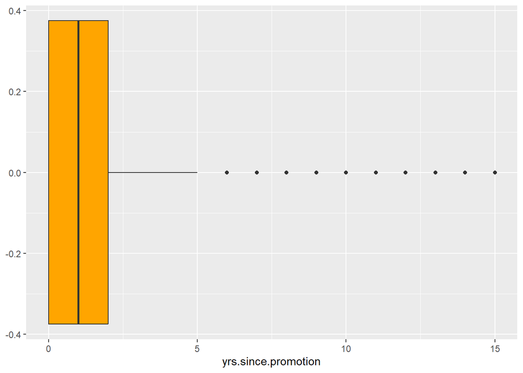

```r
ggplot(employee_data, mapping = aes(yrs.since.promotion)) +
  geom_boxplot(fill = "orange")
```

```r
# Calculate Q1, Q3, and IQR
promo_q1 <- quantile(employee_data$yrs.since.promotion, 0.25)
promo_q3 <- quantile(employee_data$yrs.since.promotion, 0.75)
promo_iqr <- promo_q3 - promo_q1

# Define lower and upper bounds
promo_lb <- promo_q1 - 1.5 * promo_iqr
promo_ub <- promo_q3 + 1.5 * promo_iqr

# Extract outliers
promo_outliers <- employee_data$yrs.since.promotion[employee_data$yrs.since.promotion < promo_lb | employee_data$yrs.since.promotion > promo_ub]

# Print outliers
head(employee_data[employee_data$yrs.since.promotion < promo_lb |employee_data$yrs.since.promotion > promo_ub, ], 12)
```

```
##    gender age education job.level performance.rating yrs.in.current.role
## 8    Male  36         3         2                  3                   7
## 13 Female  29         4         3                  3                   9
## 36   Male  34         4         2                  4                   5
## 43 Female  33         2         3                  3                  14
## 48   Male  32         3         2                  4                   8
## 49 Female  38         5         2                  3                   3
## 50 Female  50         2         5                  3                   3
## 51 Female  59         3         3                  3                  16
## 52 Female  36         3         3                  3                  14
## 75   Male  30         3         2                  3                  10
## 76   Male  40         4         4                  4                   3
## 79   Male  46         3         3                  3                   9
##    yrs.since.promotion yrs.with.manager yrs.at.company monthly.income
## 8                    7                7              7           5237
```

[output cut: 24 more lines]

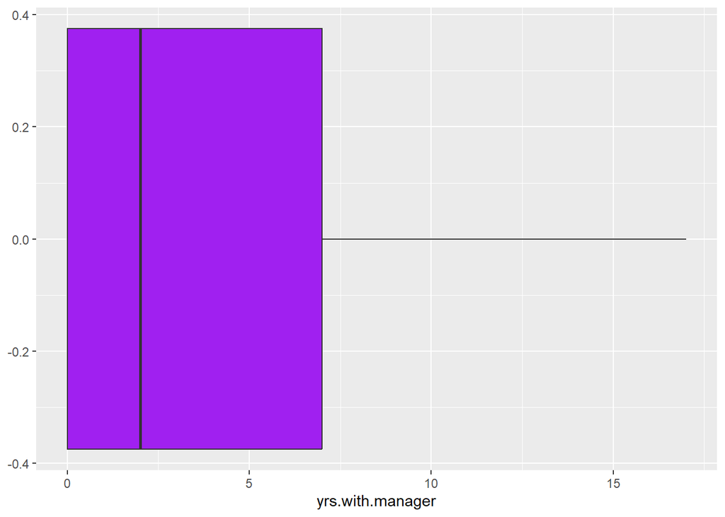

```r
ggplot(employee_data, mapping = aes(yrs.with.manager)) +
  geom_boxplot(fill = "purple")
```

```r
# Calculate Q1, Q3, and IQR
yrs_man_q1 <- quantile(employee_data$yrs.with.manager, 0.25)
yrs_man_q3 <- quantile(employee_data$yrs.with.manager, 0.75)
yrs_man_iqr <- yrs_man_q3 - yrs_man_q1

# Define lower and upper bounds
yrs_man_lb <- yrs_man_q1 - 1.5 * yrs_man_iqr
yrs_man_ub <- yrs_man_q3 + 1.5 * yrs_man_iqr

# Extract outliers
yrs_man_outliers <- employee_data$yrs.with.manager[employee_data$yrs.with.manager < yrs_man_lb | employee_data$yrs.with.manager > yrs_man_ub]

# Print outliers
head(employee_data[employee_data$yrs.with.manager < yrs_man_lb |employee_data$yrs.with.manager > yrs_man_ub, ], 12)
```

```
##  [1] gender                 age                    education
##  [4] job.level              performance.rating     yrs.in.current.role
##  [7] yrs.since.promotion    yrs.with.manager       yrs.at.company
## [10] monthly.income         job.travel.requirments at.risk
## <0 rows> (or 0-length row.names)
```

*yrs.at.company.outliers*  
These outliers follow the same pattern of non-error and appear to also be legitimate and explainable.

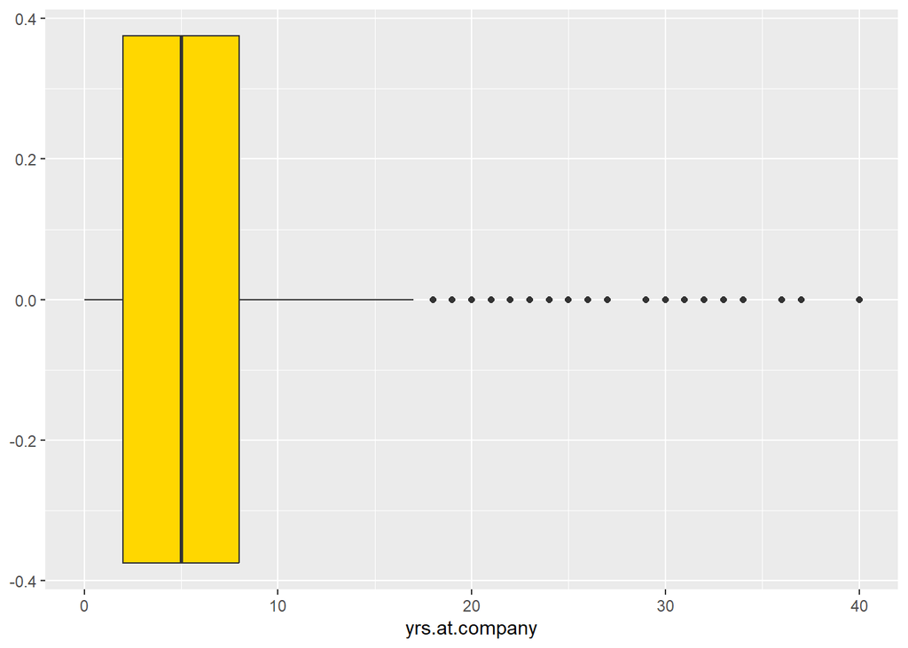

```r
ggplot(employee_data, mapping = aes(yrs.at.company)) +
  geom_boxplot(fill = "gold")
```

```r
# Calculate Q1, Q3, and IQR
yrs_comp_q1 <- quantile(employee_data$yrs.at.company, 0.25)
yrs_comp_q3 <- quantile(employee_data$yrs.at.company, 0.75)
yrs_comp_iqr <- yrs_comp_q3 - yrs_comp_q1

# Define lower and upper bounds
yrs_comp_lb <- yrs_comp_q1 - 1.5 * yrs_comp_iqr
yrs_comp_ub <- yrs_comp_q3 + 1.5 * yrs_comp_iqr

# Extract outliers
yrs_comp_outliers <- employee_data$yrs.at.company[employee_data$yrs.at.company < yrs_comp_lb | employee_data$yrs.at.company > yrs_comp_ub]

# Print outliers
head(employee_data[employee_data$yrs.at.company < yrs_comp_lb |employee_data$yrs.at.company > yrs_comp_ub, ], 12)
```

```
##     gender age education job.level performance.rating yrs.in.current.role
## 16  Female  53         4         4                  3                   8
## 23  Female  44         4         3                  3                   6
## 50  Female  50         2         5                  3                   3
## 51  Female  59         3         3                  3                  16
## 76    Male  40         4         4                  4                   3
## 84    Male  58         4         4                  3                  10
## 101   Male  43         2         4                  3                  12
## 104   Male  51         3         5                  3                  18
## 125 Female  40         3         2                  3                   7
## 151 Female  46         2         3                  4                  13
## 158 Female  40         1         5                  3                   8
## 159   Male  55         4         5                  3                  15
##     yrs.since.promotion yrs.with.manager yrs.at.company monthly.income
## 16                    3                7             25          15427
```

[output cut: 24 more lines]

*monthly.income outliers*  
Monthly income does not have disbursed outliers. The outliers appear to be a steadily increasing handful of highly paid employees. No error appears to exist.

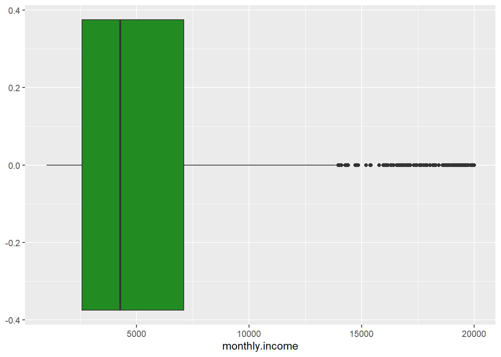

```r
ggplot(employee_data, mapping = aes(monthly.income)) +
  geom_boxplot(fill = "forest green")
```

```r
# Calculate Q1, Q3, and IQR
mo_inc_q1 <- quantile(employee_data$monthly.income, 0.25)
mo_inc_q3 <- quantile(employee_data$monthly.income, 0.75)
mo_inc_iqr <- mo_inc_q3 - mo_inc_q1

# Define lower and upper bounds
mo_inc_lb <- mo_inc_q1 - 1.5 * mo_inc_iqr
mo_inc_ub <- mo_inc_q3 + 1.5 * mo_inc_iqr

# Extract outliers
mo_inc_outliers <- employee_data$monthly.income[employee_data$monthly.income < mo_inc_lb | employee_data$monthly.income > mo_inc_ub]

# Print outliers
head(employee_data[employee_data$monthly.income < mo_inc_lb |employee_data$monthly.income > mo_inc_ub, ], 12)
```

```
##     gender age education job.level performance.rating yrs.in.current.role
## 16  Female  53         4         4                  3                   8
## 21  Female  53         3         5                  3                  13
## 24  Female  46         4         5                  3                   2
## 50  Female  50         2         5                  3                   3
## 53  Female  55         3         4                  3                   0
## 89  Female  59         4         5                  4                   2
## 90  Female  50         3         5                  3                   3
## 94  Female  54         3         4                  3                   3
## 101   Male  43         2         4                  3                  12
## 104   Male  51         3         5                  3                  18
## 122   Male  41         3         4                  3                   6
## 140 Female  50         3         5                  3                   4
##     yrs.since.promotion yrs.with.manager yrs.at.company monthly.income
## 16                    3                7             25          15427
```

[output cut: 24 more lines]

**Descriptive Statistics for Categorical features**  
By reviewing tables and visualizations, I get a good impression of my data. There are more male employees in the sample than female. Education levels among employees are as one would generally expect. *performance.rating* frequency distributions are interesting. All employees have a rating value of either *3* or *4* translating to *meeting expectations* or *exceeding expectations*. The majority are *3*, *meeting expectations*. Domain knowledge suggests that the distribution of the *3* and the *4* performance ratings are in line with expectations. However, it’s unexpected not to have any *1* or *2* ratings, *does not meet expectations* and *approaching expectations*. I’ll make a mental note of this insight for now. As I learn more about this feature, I may decide to remove it. Lastly, I see that most employees fall into the *travel rarely* class of *job.travel.requirements*.

*Frequency Distributions of Categorical Data*

```r
# review frequency distributions of categorical features
desc_stat_cat_vars <- employee_data[c("at.risk", "gender", "education", "job.level", "performance.rating", "job.travel.requirments")]

summary(desc_stat_cat_vars)
```

```
##  at.risk       gender     education job.level performance.rating
##  No :1233   Female: 935   1: 304    1:1185    3:2094
##  Yes:1233   Male  :1531   2: 474    2: 726    4: 372
##                           3:1000    3: 349
##                           4: 623    4: 120
##                           5:  65    5:  86
##        job.travel.requirments
##  Non-Travel       : 199
##  Travel_Frequently: 543
##  Travel_Rarely    :1724
##
##
```

*at.risk plot*

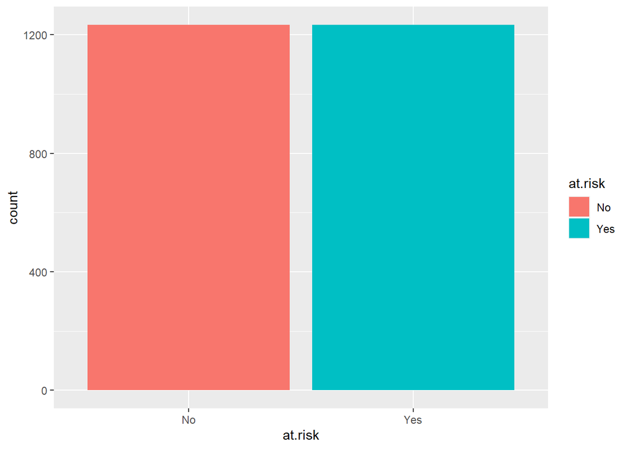

```r
ggplot(employee_data, mapping = aes(at.risk, fill = at.risk))+
  geom_bar()
```

*gender plot*

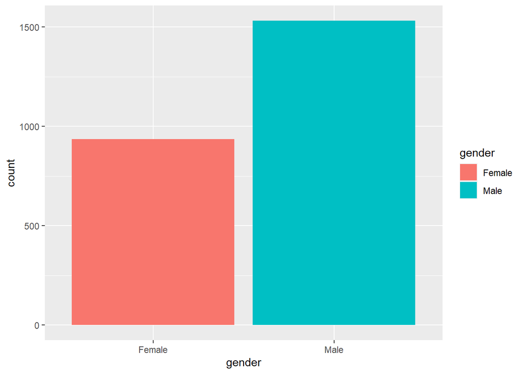

```r
ggplot(employee_data, mapping = aes(gender, fill = gender))+
  geom_bar()
```

*education plot*

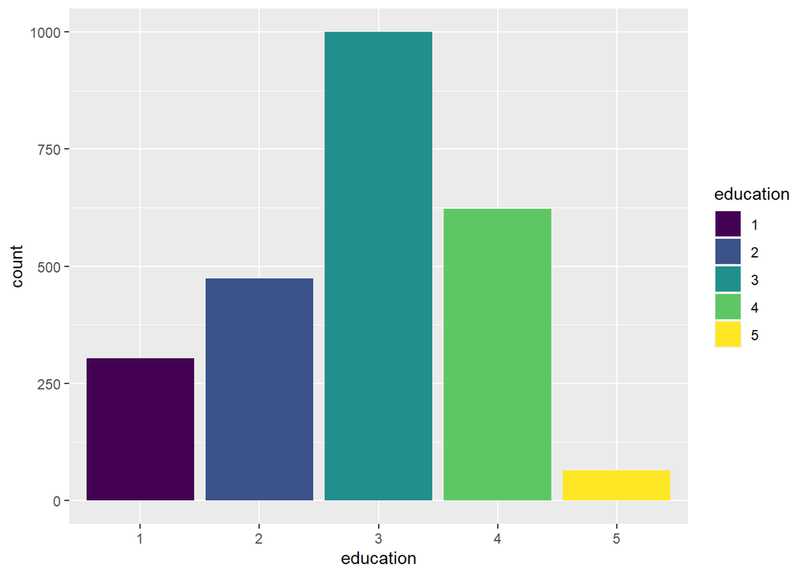

```r
ggplot(employee_data, mapping = aes(education, fill = education))+
  geom_bar()
```

*job.level plot*

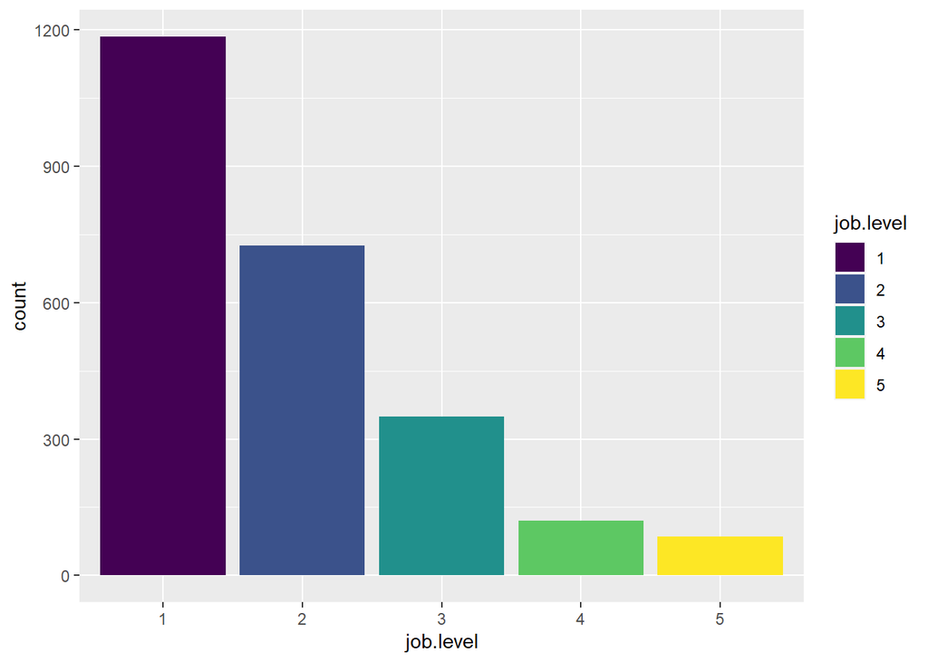

```r
ggplot(employee_data, mapping = aes(job.level, fill = job.level))+
  geom_bar()
```

*performance.rating plot*

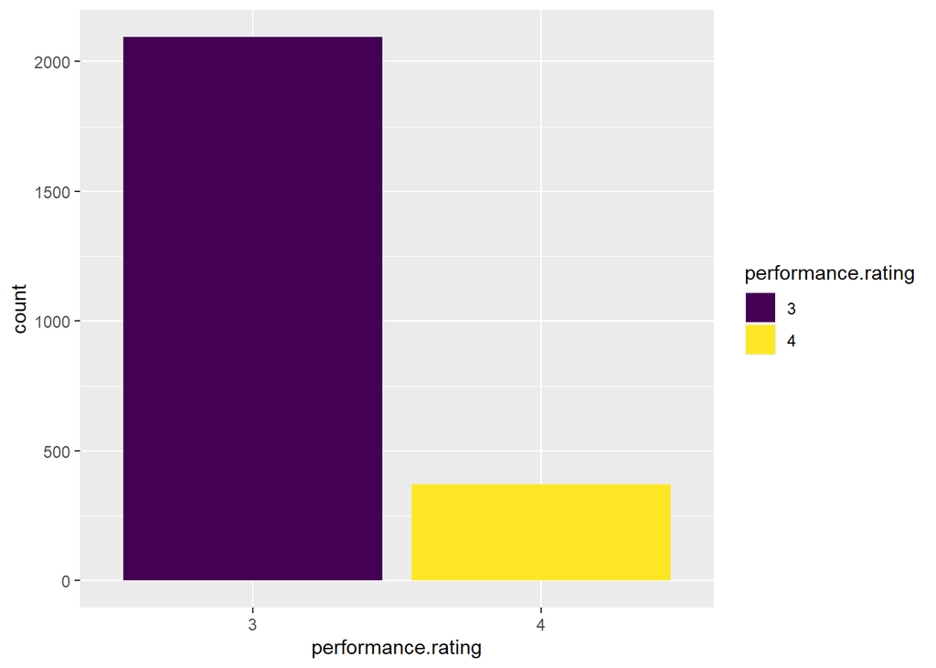

```r
ggplot(employee_data, mapping = aes(performance.rating, fill = performance.rating))+
  geom_bar()
```

*job.travel.requirements plot*

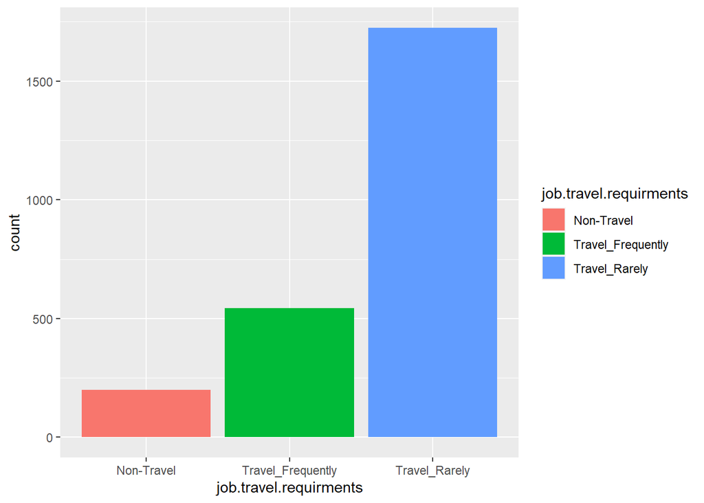

```r
ggplot(employee_data, mapping = aes(job.travel.requirments, fill = job.travel.requirments))+
  geom_bar()
```

**Correlation Analysis**  
Now that I have a baseline for my data, I explore relationships between features and the target.

**Correlation Matrix for numerical features**  
This correlation matrix shows that all correlations are positive as shown by non-negative pairwise coefficient correlation calculations, and by the absence of red in the matrix plot.The strongest positive correlations exist between the *yrs.at.company*, *yrs.with.manager*, and *yrs.in.current.role* features. Several of these relationships have coefficient of over 0.70 indicating a strong relationship. There is some concern for multicollinearity given these strong relationships.

```r
# check for correlation in numerical features
cor_matrix <- cor(desc_stat_num_vars)

cor_matrix
```

```
##                           age yrs.in.current.role yrs.since.promotion
## age                 1.0000000           0.3165685           0.2875349
## yrs.in.current.role 0.3165685           1.0000000           0.5980983
## yrs.since.promotion 0.2875349           0.5980983           1.0000000
## yrs.with.manager    0.2847541           0.7527348           0.5656936
## yrs.at.company      0.3929633           0.7873777           0.6670164
## monthly.income      0.5093140           0.4523935           0.4009680
##                     yrs.with.manager yrs.at.company monthly.income
## age                        0.2847541      0.3929633      0.5093140
## yrs.in.current.role        0.7527348      0.7873777      0.4523935
## yrs.since.promotion        0.5656936      0.6670164      0.4009680
## yrs.with.manager           1.0000000      0.7693439      0.4219304
## yrs.at.company             0.7693439      1.0000000      0.5633894
## monthly.income             0.4219304      0.5633894      1.0000000
```

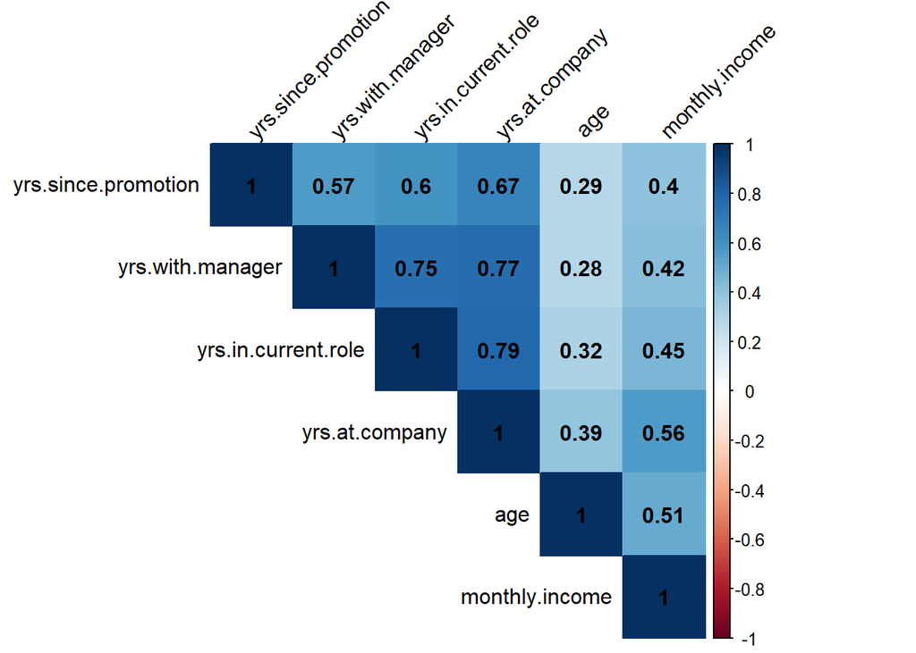

```r
#heatmap visual
corrplot(cor_matrix, method = "color", type = "upper", order = "hclust",
         addCoef.col = "black", tl.col = "black", tl.srt = 45)
```

**Model to access categorical correlation**  
Next I fit a logistic regression model to my data and summarize the results. This helps me understand additional correlations in my categorical features. The deviance residuals express a good model fit considering deviations from actual to estimate. Statistically significant features with p-values of less than 0.05 include gender, age, job.level, yrs.since.promotion. yrs.with.manager, yrs.with.manager, monthly .income, and job.travel. These features have the greatest impact on the outcome of the target.Reviewing the generalized VIF (GVIF), I see that multicollinearity is likely an issue with the *yrs.with.manager* feature. GVIF is equal to more than 2 indicating multicollinearity. Additionally, GVIF shows me that *monthly.income* may also pose multicollinearity issues. Given what I’ve learned up to now, *monthly.income* multicollinearity is probably linked to several other features.

In brief summary, I find that as age increases, employees become less at risk of leaving. An employees education level has less of an effect on their attrition than other factors. Job level is connected to attrition, especially at the highest level, *senior leadership*. More yrs without a promotion increases the risk of an employee leaving. More yrs under the same manager, and a higher monthly income lesson the chance of an employee leaving. lastly, more job travel requirements lead to increased chances of an employee leaving.

```r
logit_model <- glm(at.risk ~ gender + age + education + job.level + performance.rating + yrs.since.promotion + yrs.at.company + yrs.in.current.role + yrs.with.manager + monthly.income + job.travel.requirments, data = employee_data, family = binomial)

# Summary of the model
summary(logit_model)
```

```
##
## Call:
## glm(formula = at.risk ~ gender + age + education + job.level +
##     performance.rating + yrs.since.promotion + yrs.at.company +
##     yrs.in.current.role + yrs.with.manager + monthly.income +
##     job.travel.requirments, family = binomial, data = employee_data)
##
## Deviance Residuals:
##     Min       1Q   Median       3Q      Max
## -1.9330  -1.0113   0.1510   0.9819   2.2218
##
## Coefficients:
##                                           Estimate Std. Error z value Pr(>|z|)
## (Intercept)                              7.108e-01  4.743e-01   1.499   0.1339
## genderMale                               2.511e-01  9.310e-02   2.697   0.0070
## age                                     -2.737e-02  5.637e-03  -4.855 1.20e-06
## education.L                             -1.406e-01  2.026e-01  -0.694   0.4874
## education.Q                             -2.991e-01  1.744e-01  -1.716   0.0862
## education.C                              4.402e-02  1.309e-01   0.336   0.7366
## education^4                             -1.464e-01  9.278e-02  -1.578   0.1145
## job.level.L                              1.110e-01  5.447e-01   0.204   0.8385
## job.level.Q                              3.909e-01  1.810e-01   2.159   0.0308
## job.level.C                              1.670e-01  2.021e-01   0.826   0.4088
## job.level^4                              1.098e+00  1.636e-01   6.712 1.91e-11
## performance.rating.L                    -7.150e-03  8.865e-02  -0.081   0.9357
## yrs.since.promotion                      1.298e-01  2.104e-02   6.172 6.76e-10
## yrs.at.company                           2.976e-02  1.647e-02   1.807   0.0707
## yrs.in.current.role                     -1.198e-01  2.454e-02  -4.883 1.05e-06
## yrs.with.manager                        -1.161e-01  2.312e-02  -5.024 5.06e-07
## monthly.income                          -8.384e-05  3.725e-05  -2.251   0.0244
## job.travel.requirmentsTravel_Frequently  1.335e+00  1.960e-01   6.809 9.80e-12
## job.travel.requirmentsTravel_Rarely      8.276e-01  1.778e-01   4.656 3.23e-06
##
## (Intercept)
## genderMale                              **
## age                                     ***
## education.L
## education.Q                             .
## education.C
## education^4
## job.level.L
## job.level.Q                             *
## job.level.C
## job.level^4                             ***
## performance.rating.L
## yrs.since.promotion                     ***
## yrs.at.company                          .
## yrs.in.current.role                     ***
## yrs.with.manager                        ***
## monthly.income                          *
## job.travel.requirmentsTravel_Frequently ***
## job.travel.requirmentsTravel_Rarely     ***
## ---
## Signif. codes:  0 '***' 0.001 '**' 0.01 '*' 0.05 '.' 0.1 ' ' 1
##
## (Dispersion parameter for binomial family taken to be 1)
##
##     Null deviance: 3418.6  on 2465  degrees of freedom
## Residual deviance: 2923.5  on 2447  degrees of freedom
## AIC: 2961.5
##
## Number of Fisher Scoring iterations: 4
```

```r
# Review multicollinearity again using Variance Inflation Factor(VIF)
vif(logit_model)
```

```
##                             GVIF Df GVIF^(1/(2*Df))
## gender                  1.019966  1        1.009934
## age                     1.394316  1        1.180812
## education               1.173325  4        1.020181
## job.level              13.157332  4        1.380054
## performance.rating      1.018932  1        1.009422
## yrs.since.promotion     2.144224  1        1.464317
## yrs.at.company          4.311110  1        2.076321
## yrs.in.current.role     3.134446  1        1.770437
## yrs.with.manager        2.753048  1        1.659231
## monthly.income         11.007972  1        3.317826
## job.travel.requirments  1.050569  2        1.012409
```

*performance.rating* does not significantly impact the target. Given earlier findings, i choose to reduce dimensions and eliminate this feature altogether. Additionally, I remove the *yrs.with.manager* and the *monthly.income* feature due their multicollinearity issues.

```r
# remove performance.rating feature.
employee_data <- employee_data %>%
  select(-performance.rating, -yrs.with.manager, -monthly.income)
```

```r
# Create confusion matrix
emp_logit <- rpart(at.risk ~., data = employee_data)

emp_logit_pred <- predict(emp_logit, employee_data, type = "class")

confusionMatrix(emp_logit_pred, employee_data$at.risk)
```

```
## Confusion Matrix and Statistics
##
##           Reference
## Prediction  No Yes
##        No  871 382
##        Yes 362 851
##
##                Accuracy : 0.6983
##                  95% CI : (0.6798, 0.7164)
##     No Information Rate : 0.5
##     P-Value [Acc > NIR] : <2e-16
##
##                   Kappa : 0.3966
##
##  Mcnemar's Test P-Value : 0.4861
##
##             Sensitivity : 0.7064
##             Specificity : 0.6902
##          Pos Pred Value : 0.6951
##          Neg Pred Value : 0.7016
##              Prevalence : 0.5000
##          Detection Rate : 0.3532
##    Detection Prevalence : 0.5081
##       Balanced Accuracy : 0.6983
##
##        'Positive' Class : No
##
```

## Begin Machine Learning process

Now that I have a strong understanding of my data, I prepare it for logistic regression machine learning, I start by partitioning the data into training and validation sets. I then create a task and a learner for the training partition. I then train the model on the training data.

```r
# set seed to ensure reproducibility in future
set.seed(112)

# partition data into 80% training purposes and 20% validation purposes.
train_index <- sample(row.names(employee_data), 0.80*dim(employee_data)[1])
valid_index <- setdiff(row.names(employee_data), train_index)

train_ar <- employee_data[train_index,]
valid_ar <- employee_data[valid_index,]
```

```r
# create a classification task indicting at.risk as the target.
at_risk_logit_task <- TaskClassif$new(id = "logit_task", backend = train_ar, target = "at.risk")
```

```r
# create a learner specifying logistic regression
at_risk_logit_learner <- lrn("classif.log_reg", predict_type = "prob")
```

```r
# train the model on the training partition
ar_logit <- at_risk_logit_learner$train(at_risk_logit_task)
```

```r
# create a classification task for the validation data
valid_task <- TaskClassif$new(id = "valid_task", backend = valid_ar, target = "at.risk")

# Predict on the validation dataset
pred <- at_risk_logit_learner$predict(valid_task)
```

```r
# Get predicted classes
predicted_classes <- pred$response
true_classes <- valid_ar$at.risk

# Create a confusion matrix

confusionMatrix(as.factor(predicted_classes), as.factor(true_classes))
```

```
## Confusion Matrix and Statistics
##
##           Reference
## Prediction  No Yes
##        No  147  90
##        Yes  93 164
##
##                Accuracy : 0.6296
##                  95% CI : (0.5853, 0.6723)
##     No Information Rate : 0.5142
##     P-Value [Acc > NIR] : 1.537e-07
##
##                   Kappa : 0.2583
##
##  Mcnemar's Test P-Value : 0.8825
##
##             Sensitivity : 0.6125
##             Specificity : 0.6457
##          Pos Pred Value : 0.6203
##          Neg Pred Value : 0.6381
##              Prevalence : 0.4858
##          Detection Rate : 0.2976
##    Detection Prevalence : 0.4798
##       Balanced Accuracy : 0.6291
##
##        'Positive' Class : No
##
```

```r
# Get predicted probabilities
predicted_probs <- pred$prob[, "Yes"]

# Calculate ROC-AUC
roc_obj <- roc(true_classes, predicted_probs)
auc(roc_obj)  # Print AUC value
```

```
## Area under the curve: 0.6993
```

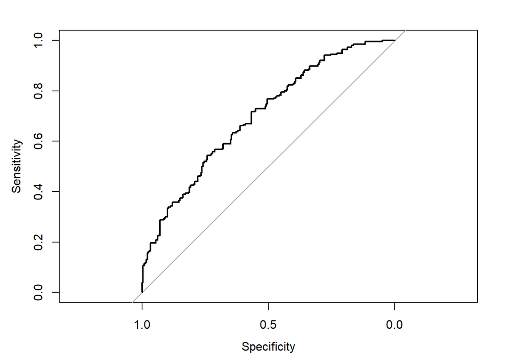

```r
plot(roc_obj) # Plot the ROC curve
```

**Closing Statement**